# HW04

許祐瑄

2017年5月13日

```r
setwd("C:/Users/asus/Dropbox/R Language Thursday/HW04")
english_course <- read.csv("english_course.csv", sep=",", header=TRUE)
number_of_exchange_students <- read.csv("exchange_students.csv", sep=",", header=TRUE)
contract <- read.csv("contract.csv", sep=",", header=TRUE)
```

```r
library(ggplot2)
#建立data frame
n <- ncol(english_course)
Newtable <- data.frame()

for (i in 3:n){
  table <- as.matrix(english_course[1:7,i])
  table2 <- as.matrix(number_of_exchange_students[15:21,i])
  table3 <- as.matrix(contract[28:34,i])
  temp <- cbind(table, table2,table3)
  Newtable <- rbind(temp,Newtable)
}

data <- data.frame(rep(colnames(english_course)[3:13],each=7),Newtable)
colnames(data) <- c("department","English_courses", "Exchange_students","Contracts")
data
```

```
##                                         department English_courses
## 1                          College.of.Liberal.Arts              21
## 2                          College.of.Liberal.Arts              39
## 3                          College.of.Liberal.Arts              29
## 4                          College.of.Liberal.Arts              26
## 5                          College.of.Liberal.Arts              30
## 6                          College.of.Liberal.Arts              28
## 7                          College.of.Liberal.Arts              30
## 8                               College.of.Science              28
## 9                               College.of.Science              17
## 10                              College.of.Science              12
## 11                              College.of.Science              24
## 12                              College.of.Science              25
## 13                              College.of.Science              18
## 14                              College.of.Science              24
```

[output cut: 141 more lines]

從下面這張圖來看，是2007年至2013年各學院的英語授課數量及交換生人數總和。以交換生人數癌看，以工學院最多，其次則為生命科學院、公衛學院；以英語授課數量來看的話，則是以生命科學院最多，再者是農學院(college of biology)及工學院。可以發現，雖然公衛學院有眾多的交換學生，但提供的英語授課卻並不多。

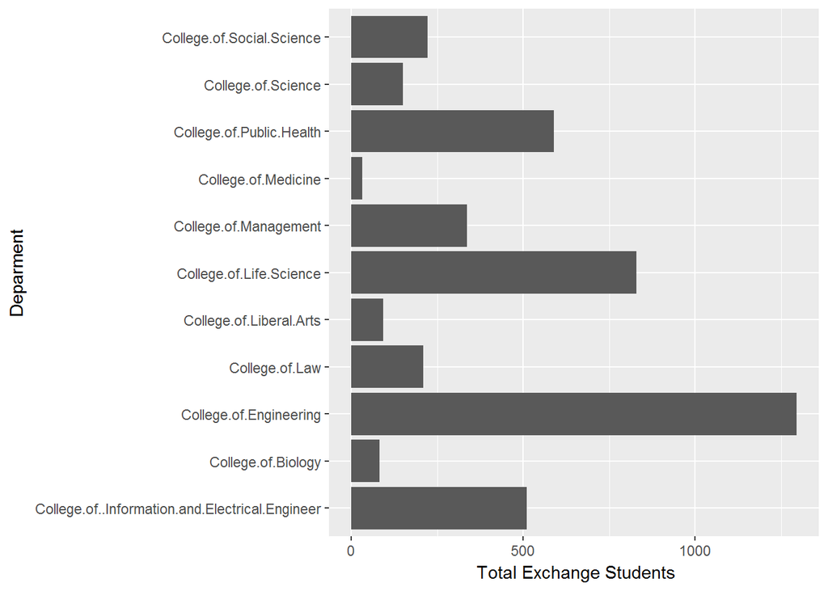

```r
#畫各學院交換生人數及英語授課數量
ggplot(data=data, aes(y=Exchange_students, x=department))+ geom_bar(stat = "identity") +coord_flip() + labs(x="Deparment", y=" Total Exchange Students")
```

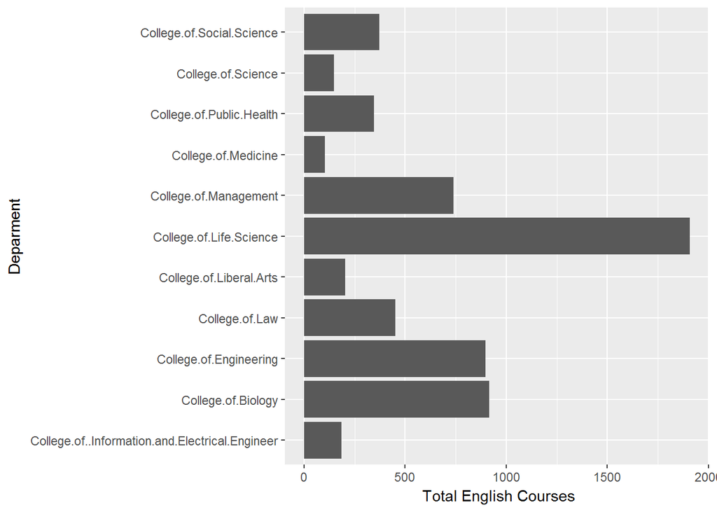

```r
ggplot(data=data, aes(y=data[,2], x=department))+ geom_bar(stat = "identity") +coord_flip() + labs(x="Deparment", y=" Total English Courses")
```

從平均數來看，農學院平均每位交換生可以有11門外語課程可以選擇，其次其為醫藥學院，然而交換生人數最多的工學院卻僅有0.69門，其他學院也大約僅有1-3門課左右。

```r
#不同學院下英語授課平均數
t1 <- tapply(data[,2], data[,1],mean)
#不同學院下交換生平均人數
t2 <-tapply(data[,3], data[,1],mean)
t1/t2
```

```
## College.of..Information.and.Electrical.Engineer
##                                       0.3607843
##                              College.of.Biology
##                                      11.0240964
##                          College.of.Engineering
##                                       0.6926641
##                                  College.of.Law
##                                       2.1523810
##                         College.of.Liberal.Arts
##                                       2.1827957
##                         College.of.Life.Science
##                                       2.2987952
##                           College.of.Management
##                                       2.1958457
##                             College.of.Medicine
##                                       3.1515152
##                        College.of.Public.Health
##                                       0.5891341
##                              College.of.Science
##                                       0.9866667
##                       College.of.Social.Science
##                                       1.6756757
```

```r
#ANOVA檢定，英語授課與交換生人數關係
anova(m1 <- lm(data[,2]~ Exchange_students, data=data))
```

```
## Analysis of Variance Table
##
## Response: data[, 2]
##                   Df Sum Sq Mean Sq F value    Pr(>F)
## Exchange_students  1  89009   89009  20.534 2.173e-05 ***
## Residuals         75 325096    4335
## ---
## Signif. codes:  0 '***' 0.001 '**' 0.01 '*' 0.05 '.' 0.1 ' ' 1
```

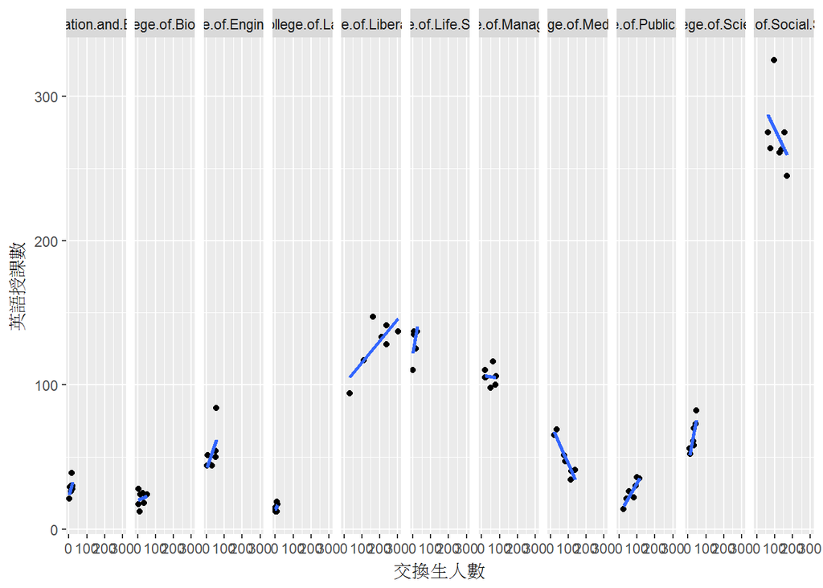

```r
#英語授課數與交換生人數關係圖，依照學院分
ggplot(data=data, aes(group=department, x=data[,3], y= data[,2])) + geom_point() + stat_smooth(method="lm", se=F)+stat_smooth(aes(group=department, x=data[,3], y= data[,2]),method="lm", se=F)+facet_grid(.~department)+labs(x="交換生人數", y="英語授課數")
```

```r
#將合約數納入考量，做ANOVA檢定
anova(m2 <- update(m1, .~.+Contracts, data=data))
```

```
## Analysis of Variance Table
##
## Response: data[, 2]
##                   Df Sum Sq Mean Sq F value    Pr(>F)
## Exchange_students  1  89009   89009 21.6702 1.391e-05 ***
## Contracts          1  21147   21147  5.1484   0.02618 *
## Residuals         74 303949    4107
## ---
## Signif. codes:  0 '***' 0.001 '**' 0.01 '*' 0.05 '.' 0.1 ' ' 1
```

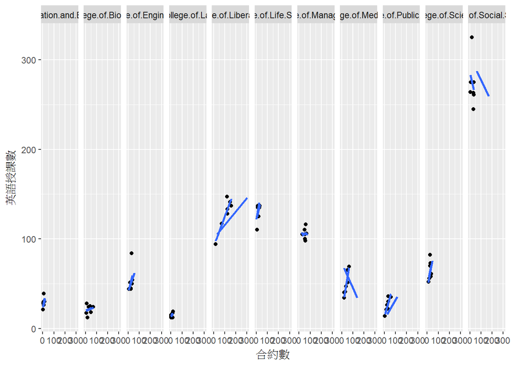

```r
#合約數與交換生人樹關係圖，按照學院分
ggplot(data=data, aes(group=department, x=data[,4], y= data[,2])) + geom_point() + stat_smooth(method="lm", se=F)+stat_smooth(aes(group=department, x=data[,3], y= data[,2]),method="lm", se=F)+facet_grid(.~department)+labs(x="合約數", y="英語授課數")
```

若考慮效果，可以發現交換生人數的效果要比學生人數來得強。但這可能會因素是合約的內容，包括限定的人數， 一個合約可能核定多數交換學生名額，因此可能會有所偏誤。

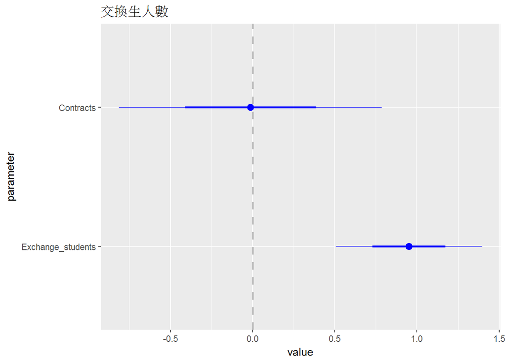

```r
#將結果放進list
res.lm <- lapply(list(m1,m2),summary)

#畫效果，將截距去除
library(coefplot)
effect <- lm(data=data, English_courses~Exchange_students+Contracts-1)
coefplot(effect, xlab="value", "parameter", title="交換生人數")
```

補充資料

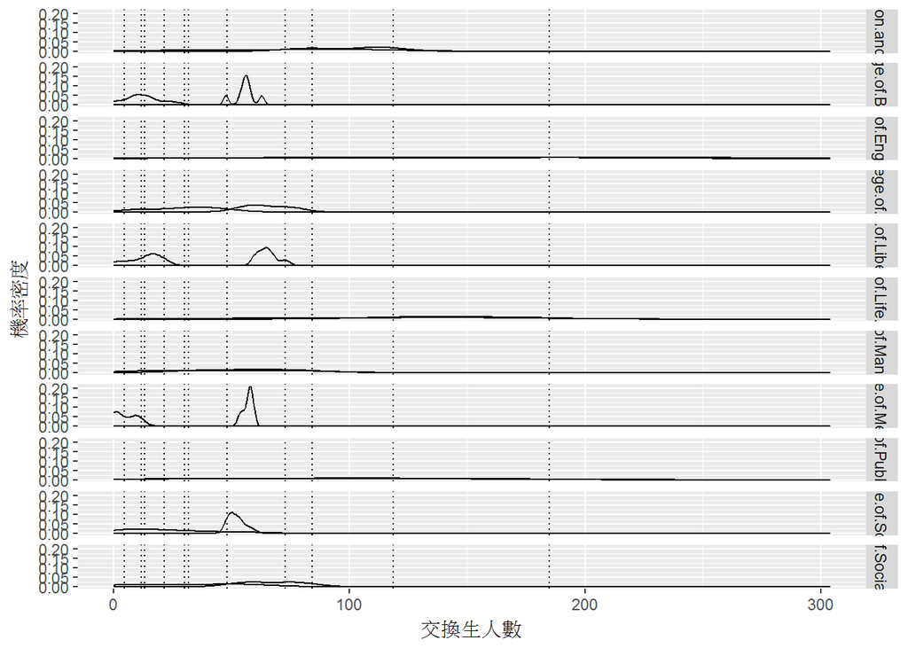

```r
fit_m2 <- data.frame(data,fitted=fitted(m2),resid=resid(m2),infl=influence(m2)$hat)
ggplot(data=fit_m2, aes(x=Exchange_students, group=department)) +
  stat_density(geom="path",position="identity")+
  stat_density(geom="path",position="identity", aes(x=fitted)) +
  geom_vline(xintercept=c(with(data, tapply(Exchange_students,department,mean))), linetype="dotted")+
  facet_grid( department ~.)+
  labs(x="交換生人數", y="機率密度")
```